# Government Supplier Prediction Project

Alana Rutherford, 500953715, Supervisor Derya Kici, Ph.D, November 28, 2021

## Data Import

```python
import pandas as pd
import numpy as np
import matplotlib.pyplot as plt
import seaborn as sn
import zipfile

with zipfile.ZipFile('data/tpsgc-pwgsc_co-ch_tous-all.zip', 'r') as zip_ref:
    zip_ref.extractall('data')
contractHistory = pd.read_csv('data/tpsgc-pwgsc_co-ch_tous-all.csv', usecols = range(0,42))
```

## General Data Description

```python
contractHistory.columns
```

```
Index(['contract-number', 'amendment-number', 'award-date', 'expiry-date',
       'contract-value', 'gsin', 'gsin-description_en', 'gsin-description_fr',
       'competitive-tender_en', 'competitive-tender_fr',
       'limited-tender-reason', 'limited-tender-reason-description_en',
       'limited-tender-reason-description_fr', 'solicitation-procedure',
       'solicitation-procedure-description_en',
       'solicitation-procedure-description_fr', 'trade-agreement',
       'trade-agreement-description_en', 'trade-agreement-description_fr',
       'supplier-standardized-name', 'supplier-operating-name',
       'supplier-legal-name', 'supplier-address-city',
       'supplier-address-prov-state', 'supplier-address-postal-code',
       'supplier-address-country', 'organization-employee-count_en',
       'organization-employee-count_fr', 'total-contract-value',
       'number-records', 'end-user-entity_en', 'end-user-entity_fr',
       'contracting-entity-office-name_en',
       'contracting-entity-office-name_fr', 'contracting-address-street-1',
       'contracting-address-street-2', 'contracting-address-city',
       'contracting-address-prov-state', 'contracting-address-postal-code',
       'contracting-address-country', 'procurement-entity-name_en',
       'procurement-entity-name_fr'],
      dtype='object')
```

```python
contractHistory.head()
```

|  | contract-number | amendment-number | award-date | expiry-date | contract-value | gsin | gsin-description_en | gsin-description_fr | competitive-tender_en | competitive-tender_fr | ... | contracting-entity-office-name_en | contracting-entity-office-name_fr | contracting-address-street-1 | contracting-address-street-2 | contracting-address-city | contracting-address-prov-state | contracting-address-postal-code | contracting-address-country | procurement-entity-name_en | procurement-entity-name_fr |
| --- | --- | --- | --- | --- | --- | --- | --- | --- | --- | --- | --- | --- | --- | --- | --- | --- | --- | --- | --- | --- | --- |
| 0 | F2599-090025/001/MD | 000 | 2009-06-16 | 2009-10-20 | 30174.0 | N1990 | Vessels, Miscellaneous | Bateaux divers | Yes | Oui | ... | CCG CENTRAL&ARCTIC RGN | N/D | MARINE ENGINEERING | 520 EXMOUTH ST | SARNIA | Ontario | N7T8B1 | Canada | Public Works and Government Services Canada | Travaux publics et Services gouvernementaux Ca... |
| 1 | F2599-090025/001/MD | 001 | 2009-07-15 | 2009-10-20 | 4876.0 | N1990 | Vessels, Miscellaneous | Bateaux divers | Yes | Oui | ... | CCG CENTRAL&ARCTIC RGN | N/D | MARINE ENGINEERING | 520 EXMOUTH ST | SARNIA | Ontario | N7T8B1 | Canada | Public Works and Government Services Canada | Travaux publics et Services gouvernementaux Ca... |
| 2 | F2599-090025/001/MD | 002 | 2009-07-20 | 2009-10-20 | 26914.0 | N1990 | Vessels, Miscellaneous | Bateaux divers | Yes | Oui | ... | CCG CENTRAL&ARCTIC RGN | N/D | MARINE ENGINEERING | 520 EXMOUTH ST | SARNIA | Ontario | N7T8B1 | Canada | Public Works and Government Services Canada | Travaux publics et Services gouvernementaux Ca... |
| 3 | E60LP-090002/392/LP | 000 | 2010-01-01 | 2010-12-31 | 25000.0 | V502B | Hotels, Motels and Commercial Accommodation | Hôtels, motels et logements commerciaux | Yes | Oui | ... | CONSOLIDATED PROC LP ICPSS | N/D | PORTAGE III 7B3 | 11 LAURIER ST | GATINEAU | Quebec | K1A0S5 | Canada | Public Works and Government Services Canada | Travaux publics et Services gouvernementaux Ca... |
| 4 | E60LP-110001/050/LP | 000 | 2012-01-01 | 2012-12-31 | 25000.0 | V502B | Hotels, Motels and Commercial Accommodation | Hôtels, motels et logements commerciaux | Yes | Oui | ... | CONSOLIDATED PROC LP ICPSS | N/D | PORTAGE III 7B3 | 11 LAURIER ST | GATINEAU | Quebec | K1A0S5 | Canada | Public Works and Government Services Canada | Travaux publics et Services gouvernementaux Ca... |

5 rows × 42 columns

```python
contractHistory.info()
```

```
<class 'pandas.core.frame.DataFrame'>
RangeIndex: 441210 entries, 0 to 441209
Data columns (total 42 columns):
 #   Column                                 Non-Null Count   Dtype
---  ------                                 --------------   -----
 0   contract-number                        441210 non-null  object
 1   amendment-number                       441210 non-null  object
 2   award-date                             441210 non-null  object
 3   expiry-date                            441210 non-null  object
 4   contract-value                         441210 non-null  float64
 5   gsin                                   441199 non-null  object
 6   gsin-description_en                    441199 non-null  object
 7   gsin-description_fr                    441210 non-null  object
 8   competitive-tender_en                  441210 non-null  object
 9   competitive-tender_fr                  441210 non-null  object
```

[output cut: 34 more lines]

## Attribute Data Description

Includes use of describe to obtain the count and unique, and use of value count to identify the top most frequent attributes. This was completed for all categorical attributes that were not considered duplicates on initial analysis. For the sake of brevity, only the describe function is provided below after the first attribute.

```python
contractHistory.describe()
```

|  | contract-value | limited-tender-reason | total-contract-value | number-records |
| --- | --- | --- | --- | --- |
| count | 4.412100e+05 | 94299.000000 | 4.412100e+05 | 441210.000000 |
| mean | 4.398310e+05 | 75.398689 | 8.457397e+06 | 8.202300 |
| std | 1.609191e+07 | 7.860150 | 1.061860e+08 | 18.275149 |
| min | -1.540262e+08 | 8.000000 | -1.985487e+08 | 1.000000 |
| 25% | 0.000000e+00 | 71.000000 | 2.096325e+04 | 1.000000 |
| 50% | 8.715000e+03 | 71.000000 | 1.268150e+05 | 3.000000 |
| 75% | 6.941075e+04 | 85.000000 | 7.749660e+05 | 6.000000 |
| max | 5.221000e+09 | 90.000000 | 5.761974e+09 | 206.000000 |

```python
contractHistory['contract-number'].describe()
```

```
count                   441210
unique                  199675
top       E0208-150548/001/PWZ
freq                       206
Name: contract-number, dtype: object
```

```python
contractHistory['contract-number'].value_counts()
```

```
E0208-150548/001/PWZ    206
EN578-110558/001/XL     162
EP008-112560/001/GC     152
EP008-112560/004/GC     139
EW038-140681/001/PWU    139
                       ...
W0113-10A128/001/BOR      1
5K003-156233/001/WPG      1
5K003-148856/001/WPG      1
W8482-128975/001/GRK      1
U4030-221421/001/HN       1
Name: contract-number, Length: 199675, dtype: int64
```

```python
contractHistory['amendment-number'].describe()
```

```
count     441210
unique       237
top          000
freq      174270
Name: amendment-number, dtype: object
```

```python
contractHistory['award-date'].describe()
```

```
count         441210
unique          4085
top       2011-01-01
freq            2277
Name: award-date, dtype: object
```

```python
contractHistory['expiry-date'].describe()
```

```
count         441210
unique          6859
top       2011-03-31
freq            9500
Name: expiry-date, dtype: object
```

```python
contractHistory['gsin'].describe()
```

```
count     441199
unique      5203
top        N7030
freq       26529
Name: gsin, dtype: object
```

```python
contractHistory['gsin-description_en'].describe()
```

```
count           441199
unique            5188
top       ADP Software
freq             26529
Name: gsin-description_en, dtype: object
```

```python
contractHistory['competitive-tender_en'].describe()
```

```
count     441210
unique         2
top          Yes
freq      346895
Name: competitive-tender_en, dtype: object
```

```python
contractHistory['limited-tender-reason-description_en'].describe()
```

```
count                94299
unique                  16
top       Exclusive Rights
freq                 57400
Name: limited-tender-reason-description_en, dtype: object
```

```python
contractHistory['solicitation-procedure-description_en'].describe()
```

```
count           441210
unique               4
top       Open Bidding
freq            269648
Name: solicitation-procedure-description_en, dtype: object
```

```python
contractHistory['trade-agreement'].describe()
```

```
count     440929
unique        35
top            I
freq      115604
Name: trade-agreement, dtype: object
```

```python
contractHistory['supplier-standardized-name'].describe()
```

```
count                                    441210
unique                                    36355
top       SIMEX DEFENCE INC / DEFENSE SIMEX INC
freq                                       4305
Name: supplier-standardized-name, dtype: object
```

```python
contractHistory['supplier-address-city'].describe()
```

```
count     441091
unique      7261
top       Ottawa
freq       80001
Name: supplier-address-city, dtype: object
```

```python
contractHistory['supplier-address-prov-state'].describe()
```

```
count      430737
unique         64
top       Ontario
freq       190079
Name: supplier-address-prov-state, dtype: object
```

```python
contractHistory['supplier-address-country'].describe()
```

```
count     441210
unique       115
top       Canada
freq      398099
Name: supplier-address-country, dtype: object
```

```python
contractHistory['supplier-address-postal-code'].describe()
```

```
count     438200
unique     27226
top       H9R1A6
freq        4305
Name: supplier-address-postal-code, dtype: object
```

```python
contractHistory['organization-employee-count_en'].describe()
```

```
count                 441208
unique                    14
top       20 to 49 employees
freq                   71520
Name: organization-employee-count_en, dtype: object
```

```python
contractHistory['end-user-entity_en'].describe()
```

```
count                                          441210
unique                                            132
top       Public Works and Government Services Canada
freq                                           182963
Name: end-user-entity_en, dtype: object
```

```python
contractHistory['contracting-entity-office-name_en'].describe()
```

```
count     431285
unique      3422
top         NDHQ
freq       19931
Name: contracting-entity-office-name_en, dtype: object
```

```python
contractHistory['contracting-address-street-1'].describe()
```

```
count                 441182
unique                  3140
top       101 COLONEL BY DR.
freq                   25490
Name: contracting-address-street-1, dtype: object
```

```python
contractHistory['contracting-address-street-2'].describe()
```

```
count            308117
unique             1561
top       11 LAURIER ST
freq              82908
Name: contracting-address-street-2, dtype: object
```

```python
contractHistory['contracting-address-city'].describe()
```

```
count     441182
unique       440
top       OTTAWA
freq      130007
Name: contracting-address-city, dtype: object
```

```python
contractHistory['contracting-address-prov-state'].describe()
```

```
count      440905
unique         13
top       Ontario
freq       166823
Name: contracting-address-prov-state, dtype: object
```

```python
contractHistory['contracting-address-postal-code'].describe()
```

```
count     441180
unique      1196
top       K1A0S5
freq      100214
Name: contracting-address-postal-code, dtype: object
```

```python
contractHistory['contracting-address-country' ].describe()
```

```
count     441182
unique         4
top       Canada
freq      440905
Name: contracting-address-country, dtype: object
```

```python
contractHistory['procurement-entity-name_en'].describe()
```

```
count                                          441210
unique                                              1
top       Public Works and Government Services Canada
freq                                           441210
Name: procurement-entity-name_en, dtype: object
```

## Visualizing Categorical Attributes

A selection of the categorical attributes have been visualized below for the sake of brevity. The full set were initially reviewed.

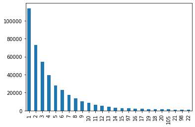

```python
#contractHistory['amendment-number'].value_counts().plot(kind = 'bar')
recordNo = contractHistory['number-records'].value_counts()
recordNo = recordNo[recordNo > 1000]
recordNo.plot(kind = 'bar')
```

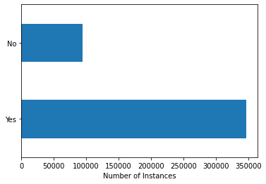

```python
contractHistory['competitive-tender_en'].value_counts().plot(kind = 'barh')
plt.xlabel('Number of Instances')
```

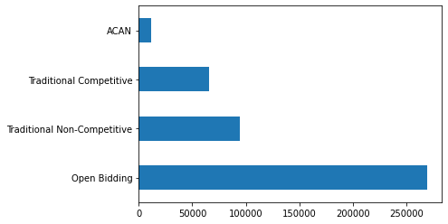

```python
contractHistory['solicitation-procedure-description_en'].value_counts().plot(kind = 'barh')
```

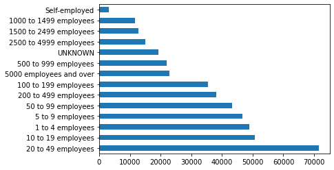

```python
contractHistory['organization-employee-count_en'].value_counts().plot(kind = 'barh')
```

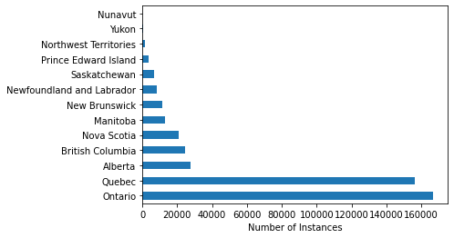

```python
contractHistory['contracting-address-prov-state'].value_counts().plot(kind = 'barh')
plt.xlabel('Number of Instances')
```

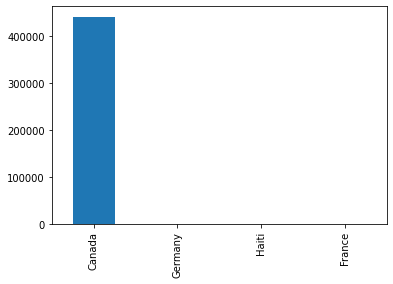

```python
contractHistory['contracting-address-country'].value_counts().plot(kind = 'bar')
```

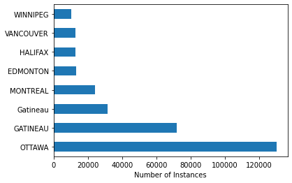

```python
locate = contractHistory['contracting-address-city'].value_counts()
locate = locate[locate > 10000]
locate.plot(kind = 'barh')
plt.xlabel('Number of Instances')
```

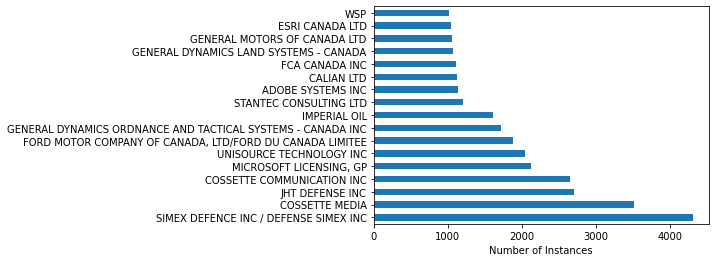

```python
recordNo = contractHistory['supplier-standardized-name'].value_counts()
recordNo = recordNo[recordNo > 1000]
recordNo.plot(kind = 'barh')
plt.xlabel('Number of Instances')
```

## Visualizing Numerical Attributes

```python
contractValue = contractHistory['contract-value'].value_counts().rename_axis('unique_values').reset_index(name='counts')
contractValue = pd.DataFrame(contractValue)
contractValue = contractValue.sort_values(by='unique_values')
```

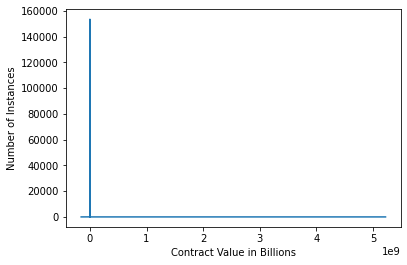

```python
plt.plot(contractValue['unique_values'],contractValue['counts'])
plt.ylabel('Number of Instances')
plt.xlabel('Contract Value in Billions')
```

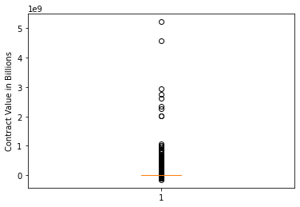

```python
plt.boxplot(contractValue['unique_values'])
plt.ylabel('Contract Value in Billions')
```

```python
totalValue = contractHistory['total-contract-value'].value_counts().rename_axis('unique_values').reset_index(name='counts')
totalValue = pd.DataFrame(totalValue)
totalValue = totalValue.sort_values(by='unique_values')
```

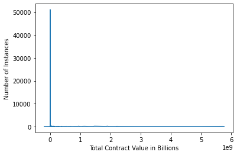

```python
plt.plot(totalValue['unique_values'],totalValue['counts'])
plt.ylabel('Number of Instances')
plt.xlabel('Total Contract Value in Billions')
```

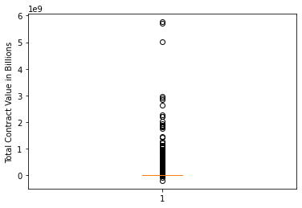

```python
plt.boxplot(totalValue['unique_values'])
plt.ylabel('Total Contract Value in Billions')
```

```python
noRecord = contractHistory['number-records'].value_counts().rename_axis('unique_values').reset_index(name='counts')
noRecord = pd.DataFrame(noRecord)
noRecord = noRecord.sort_values(by='unique_values')
```

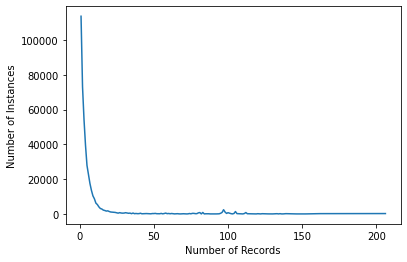

```python
plt.plot(noRecord['unique_values'],noRecord['counts'])
plt.ylabel('Number of Instances')
plt.xlabel('Number of Records')
```

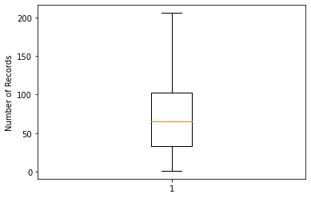

```python
plt.boxplot(noRecord['unique_values'])
plt.ylabel('Number of Records')
```

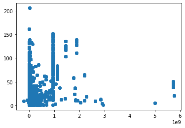

```python
plt.scatter(contractHistory['total-contract-value'],contractHistory['number-records'])
```

## Correlation Analysis

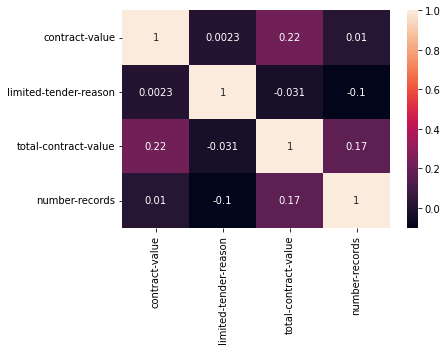

```python
corrMatrix = contractHistory.corr()
sn.heatmap(corrMatrix, annot=True)
plt.show()
```

## Removing Attributes

Duplicate attributes were removed, barring GSIN and trade agreements, since this information might help with later analysis. Procurement entity information was removed since it showed one value.

```python
editCH = contractHistory.drop(['gsin-description_fr','competitive-tender_fr','limited-tender-reason','limited-tender-reason-description_fr','solicitation-procedure','solicitation-procedure-description_fr','trade-agreement-description_en','trade-agreement-description_fr','supplier-operating-name','supplier-legal-name','organization-employee-count_fr','end-user-entity_fr','contracting-entity-office-name_fr','procurement-entity-name_en',
       'procurement-entity-name_fr'], axis = 1)
```

## Testing for Impact of Duplicate Contract Number Instances

Reviewing to determine whether duplicate contact numbers result in duplicate information elsewhere.

```python
editCH.insert(27, 'contract-number supplier test',editCH['contract-number'] + editCH['supplier-standardized-name'])
```

```python
editCH['contract-number supplier test'].value_counts()
```

```
E0208-150548/001/PWZWRIGHT CONSTRUCTION                                                                                   206
EN578-110558/001/XLWOLTERS KLUWER LTD / WOLTERS KLUWER LIMITEE                                                            162
EP008-112560/001/GCBROOKFIELD GLOBAL INTEGRATED SOLUTIONS CANADA LP/BROOKFIELD SOLUTIONS GLOBALES INTEGREES CANADA SEC    152
EW038-140681/001/PWUTRI CITY CANADA INC                                                                                   139
EP008-112560/004/GCBROOKFIELD GLOBAL INTEGRATED SOLUTIONS CANADA LP/BROOKFIELD SOLUTIONS GLOBALES INTEGREES CANADA SEC    139
                                                                                                                         ...
W8160-140026/001/PICEDROM-SNI INC                                                                                           1
08324-140303/001/EJONX ENTERPRISE SOLUTIONS LTD                                                                             1
W8486-096164/005/HSB S F (BUSINESS SOLUTIONS FASTENERS) INTERNATIONAL INC                                                   1
E60LP-100002/088/LPSHERATON VANCOUVER GUILDFORD                                                                             1
U4030-221421/001/HNSPEAG SCHMID & PARTNER ENGINEERING AG                                                                    1
Name: contract-number supplier test, Length: 200644, dtype: int64
```

```python
editCH['contract-number'].describe()
```

```
count                   441210
unique                  199675
top       E0208-150548/001/PWZ
freq                       206
Name: contract-number, dtype: object
```

```python
editCH['contract-number supplier test'].describe()
```

```
count                                      441210
unique                                     200644
top       E0208-150548/001/PWZWRIGHT CONSTRUCTION
freq                                          206
Name: contract-number supplier test, dtype: object
```

## Removing Duplicate Contract Number Instances

Since the test above indicates that there are only 969 unique instances where the supplier changes within the same contract number, representing only 0.485% of the contract numbers. The duplicate instances of contract numbers to reflect amendments were removed, as well as the contract value and amendment number, which are better reflected by the total contrat value and number of records attributes. The remaining instances reflect the first award dates of the contract numbers to capture the initial win of the contract.

```python
editCH.sort_values(['contract-number','award-date'], ascending=True, inplace=True)
editCH.insert(28, 'duplicate contract check', editCH.duplicated(subset='contract-number'))
editCH = editCH[editCH['duplicate contract check'] != True]
editCH.shape
```

```
(199675, 29)
```

```python
editCH = editCH.drop(['amendment-number', 'contract-value', 'duplicate contract check', 'contract-number supplier test'], axis = 1)
editCH.shape
```

```
(199675, 25)
```

## Creating a Parent GSIN Category

Given the high volume of unique GSIN codes, and the ability to categorize the code within a parent company by the first letter, a GSIN category attribute has been created.

[figure not shown]

```python
editCH.insert(5, 'gsin-category', editCH['gsin'].str[:1])
editCH['gsin-category'].value_counts().plot(kind = 'bar')
plt.ylabel('Number of Instances')
```

## Removing Limited Tender Reason

The information in the editCH dataset is generally filled in. However, a category with a significant amount (72.5%) missing values is the the limited tender reason column, which is a near exact match to the number of non-competitive tenders. Given the sparce data in this column, it has been removed from the dataset.

```python
editCH['contract-number'].describe()
```

```
count                   199675
unique                  199675
top       01005-010324/009/WPG
freq                         1
Name: contract-number, dtype: object
```

```python
editCH['limited-tender-reason-description_en'].describe()
```

```
count                54900
unique                  16
top       Exclusive Rights
freq                 30599
Name: limited-tender-reason-description_en, dtype: object
```

```python
(199675-54900)/199675*100
```

```
72.50532114686365
```

```python
editCH['competitive-tender_en'].value_counts()
```

```
Yes    144768
No      54907
Name: competitive-tender_en, dtype: int64
```

```python
editCH = editCH.drop(['limited-tender-reason-description_en'], axis = 1)
```

## Managing Missing Categorical Values

```python
#this cell was repeated for all attributes with missing values to assess impact
editCH['gsin-description_en'].describe()
```

```
count                                          199675
unique                                           5164
top       Hotels, Motels and Commercial Accommodation
freq                                            16657
Name: gsin-description_en, dtype: object
```

```python
editCH['contract-number'].describe()
```

```
count                   199675
unique                  199675
top       01005-010324/009/WPG
freq                         1
Name: contract-number, dtype: object
```

```python
#this cell was repeated for all attributes with missing values to assess impact
(199675-199672)/199675*100
```

```
0.0015024414673844998
```

```python
editCH = editCH.drop(['contracting-address-street-2'], axis = 1)
```

```python
#editCH.dropna(subset = ['gsin-description_en', 'end-user-entity-top', 'trade-agreement', 'supplier-address-city', 'supplier-address-postal-code', 'organization-employee-count_en', 'contracting-entity-office-name_en', 'contracting-address-street-1', 'contracting-address-prov-state', 'contracting-address-postal-code', 'contracting-address-country'], axis = 0, inplace = True)
```

```python
editCH.columns
```

```
Index(['contract-number', 'award-date', 'expiry-date', 'gsin',
       'gsin-description_en', 'gsin-category', 'competitive-tender_en',
       'solicitation-procedure-description_en', 'trade-agreement',
       'supplier-standardized-name', 'supplier-address-city',
       'supplier-address-prov-state', 'supplier-address-postal-code',
       'supplier-address-country', 'organization-employee-count_en',
       'total-contract-value', 'number-records', 'end-user-entity_en',
       'contracting-entity-office-name_en', 'contracting-address-street-1',
       'contracting-address-city', 'contracting-address-prov-state',
       'contracting-address-postal-code', 'contracting-address-country'],
      dtype='object')
```

```python
editCH.dropna(subset = ['contract-number', 'award-date', 'expiry-date', 'gsin', 'gsin-description_en', 'gsin-category', 'competitive-tender_en', 'solicitation-procedure-description_en', 'trade-agreement', 'total-contract-value', 'end-user-entity_en', 'contracting-entity-office-name_en', 'contracting-address-city', 'contracting-address-prov-state', 'contracting-address-postal-code', 'contracting-address-country'], axis = 0, inplace = True)
```

```python
editCH.shape
```

```
(194135, 24)
```

## Creating Time Series for Award Date Attribute

```python
editCH['award year']=[d.split('-')[0] for d in editCH['award-date']]
editCH['award month']=[d.split('-')[1] for d in editCH['award-date']]
editCH['award day']=[d.split('-')[2] for d in editCH['award-date']]
```

```python
editCH['award year'] = pd.to_numeric(editCH['award year'])
```

```python
awardYear = (editCH['award year'] - editCH['award year'].min()) / (editCH['award year'].max()-editCH['award year'].min())
editCH.insert(25, 'award-year-normalized',awardYear)
```

```python
editCH.insert(24, 'days-since-first-award', 'None')
```

```python
from datetime import datetime

editCH['award-date'] = editCH['award-date'].apply(pd.to_datetime)
editCH['days-since-first-award'] = (editCH['award-date'] - editCH['award-date'].min()).dt.days
editCH['days-since-first-award']
```

```
22402       89
22486      127
22488      259
279171      63
204467     243
          ...
47968     1121
91429     1145
74499     1134
285173    1175
167242     152
Name: days-since-first-award, Length: 194135, dtype: int64
```

```python
normalizedAwardDays = (editCH['days-since-first-award'] - editCH['days-since-first-award'].min()) / (editCH['days-since-first-award'].max()-editCH['days-since-first-award'].min())
editCH.insert(25, 'days-since-first-award-normalized',normalizedAwardDays)
```

## Numeric Attributes

### Total Contract Value

This data has a right skew, with negative values, a significant spike in values at 0 and 25000, and a long right tail with outliers.

```python
editCH['total-contract-value'].value_counts()
```

```
0.0          18461
25000.0      10848
1.0            982
100000.0       758
26250.0        697
             ...
3170196.0        1
615523.0         1
4769883.0        1
176914.0         1
3999.0           1
Name: total-contract-value, Length: 96040, dtype: int64
```

```python
totalContractValue = editCH['total-contract-value'].value_counts().rename_axis('unique_values').reset_index(name='counts')
totalContractValue = pd.DataFrame(totalContractValue)
totalContractValue = totalContractValue.sort_values(by = 'unique_values')
```

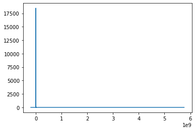

```python
plt.plot(totalContractValue['unique_values'],totalContractValue['counts'])
```

```
{'whiskers': [<matplotlib.lines.Line2D at 0x181f22421c0>,
 'caps': [<matplotlib.lines.Line2D at 0x181f2242910>,
 'boxes': [<matplotlib.lines.Line2D at 0x181f223fdf0>],
 'medians': [<matplotlib.lines.Line2D at 0x181f2243070>],
 'fliers': [<matplotlib.lines.Line2D at 0x181f2243400>],
 'means': []}
```

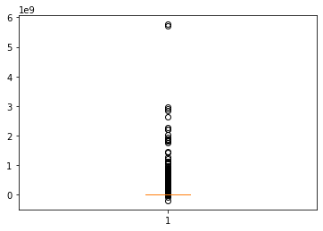

```python
plt.boxplot(totalContractValue['unique_values'])
```

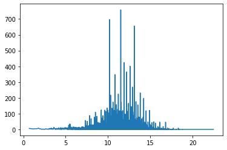

```python
test = totalContractValue[['unique_values', 'counts']]
test = test[test['unique_values'] > 1]
test = test[test['unique_values'] != 25000]
plt.plot(np.log(test['unique_values']),test['counts'])
```

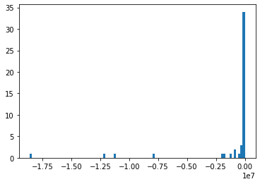

```python
test2 = totalContractValue[['unique_values', 'counts']]
test2 = test2[test2['unique_values'] < 0]
test2 = test2[test2['unique_values'] > -25000000]
plt.hist(test2['unique_values'], bins = 100)
```

```python
#This data has a lognormal distribution for the positive values when 0, 1, and 25000 are removed
```

```python
#removing two significant outliers
remove = editCH[editCH['total-contract-value'] >= 4000000000].index
editCH.drop(remove, inplace = True)
```

```
{'whiskers': [<matplotlib.lines.Line2D at 0x181f1b9bf70>,
 'caps': [<matplotlib.lines.Line2D at 0x181f1ba06d0>,
 'boxes': [<matplotlib.lines.Line2D at 0x181f1b9bbe0>],
 'medians': [<matplotlib.lines.Line2D at 0x181f1ba0df0>],
 'fliers': [<matplotlib.lines.Line2D at 0x181f1ba31c0>],
 'means': []}
```

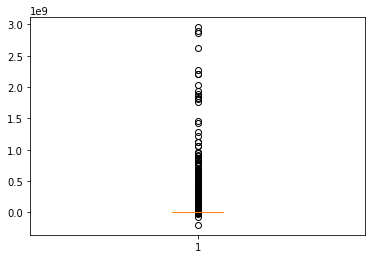

```python
plt.boxplot(editCH['total-contract-value'])
```

```python
normalizedContractValue = (editCH['total-contract-value'] - editCH['total-contract-value'].min()) / (editCH['total-contract-value'].max()-editCH['total-contract-value'].min())
editCH.insert(16, 'total-contract-value-normalized',normalizedContractValue)
```

```python
contractValueNorm = editCH['total-contract-value-normalized'].value_counts().rename_axis('unique_values').reset_index(name='counts')
contractValueNorm = pd.DataFrame(contractValueNorm)
contractValueNorm = contractValueNorm.sort_values(by='unique_values')
print(contractValueNorm)
```

```
       unique_values  counts
46268       0.000000       1
46746       0.038139       1
46156       0.057092       1
54049       0.059099       1
46246       0.059409       1
...              ...     ...
56932       0.785771       1
44460       0.896624       1
92348       0.969658       1
44286       0.982991       1
93428       1.000000       1

[96038 rows x 2 columns]
```

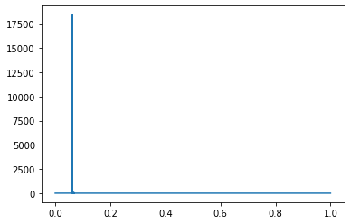

```python
plt.plot(contractValueNorm['unique_values'],contractValueNorm['counts'])
```

### Number of Records

```python
editCH['number-records'].value_counts()
```

```
1      110041
2       37463
3       17048
4        9743
5        5698
        ...
103         1
67          1
135         1
123         1
64          1
Name: number-records, Length: 105, dtype: int64
```

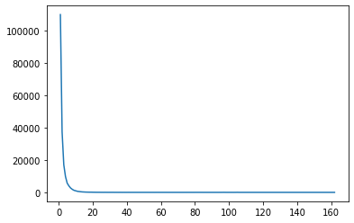

```python
noRecord = editCH['number-records'].value_counts().rename_axis('records').reset_index(name='counts')
noRecord = pd.DataFrame(noRecord)
noRecord = noRecord.sort_values(by='records')
plt.plot(noRecord['records'],noRecord['counts'])
```

```
{'whiskers': [<matplotlib.lines.Line2D at 0x181eff695b0>,
 'caps': [<matplotlib.lines.Line2D at 0x181eff69cd0>,
 'boxes': [<matplotlib.lines.Line2D at 0x181eff69220>],
 'medians': [<matplotlib.lines.Line2D at 0x181eff6d430>],
 'fliers': [<matplotlib.lines.Line2D at 0x181eff6d7c0>],
 'means': []}
```

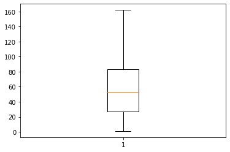

```python
plt.boxplot(noRecord['records'])
```

```python
#This data has an exponential distibution
#Since number of records does not have material impact on the outcome of the supplier award, it is being removed from this analysis
#noRecordNorm = (editCH['number-records'] - editCH['number-records'].min()) / (editCH['number-records'].max()-editCH['number-records'].min())
#editCH.insert(17, 'number-records-normalized',noRecordNorm)
```

```python
editCH = editCH.drop(['number-records'], axis = 1)
```

```python
#editCH = editCH.drop(['award year', 'award month', 'award day', 'expiry year', 'expiry month', 'expiry day'], axis = 1)
```

```python
editCH.describe()
```

|  | total-contract-value | total-contract-value-normalized | days-since-first-award | days-since-first-award-normalized | award year | award-year-normalized |
| --- | --- | --- | --- | --- | --- | --- |
| count | 1.941330e+05 | 194133.000000 | 194133.000000 | 194133.000000 | 194133.000000 | 194133.000000 |
| mean | 1.149437e+06 | 0.063351 | 1607.475597 | 0.346289 | 2012.982507 | 0.331876 |
| std | 2.434127e+07 | 0.007722 | 1310.866238 | 0.282393 | 3.570864 | 0.297572 |
| min | -1.985487e+08 | 0.000000 | 0.000000 | 0.000000 | 2009.000000 | 0.000000 |
| 25% | 1.128000e+04 | 0.062989 | 479.000000 | 0.103188 | 2010.000000 | 0.083333 |
| 50% | 4.320000e+04 | 0.063000 | 1202.000000 | 0.258940 | 2012.000000 | 0.250000 |
| 75% | 2.014690e+05 | 0.063050 | 2582.000000 | 0.556226 | 2016.000000 | 0.583333 |
| max | 2.953723e+09 | 1.000000 | 4642.000000 | 1.000000 | 2021.000000 | 1.000000 |

## Creating the Dependent Variable

To create a binary dependent variable that will determine whether a supplier will be the supplier on a contract, a new column need sto be created that flags all instances where the supplier is named and turns those instances into a Yes. All other instances will be No. The supplier to be used in this analysis is STANTEC. Note that this attribute is messy, meaning that STANTEC is named in multiple unique instances.

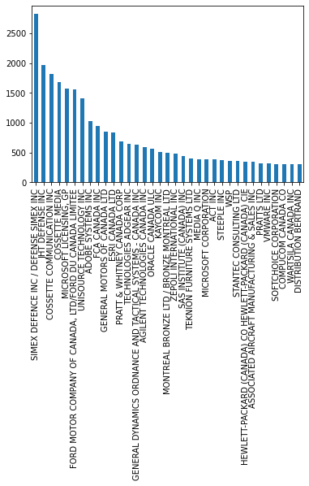

```python
topSuppliers = editCH['supplier-standardized-name'].value_counts()
topSuppliers = topSuppliers[topSuppliers > 300]
topSuppliers.plot(kind = 'bar')
```

```python
editCH.insert(9,'stantec-supplier','no')
```

```python
editCH['stantec-supplier'] = np.where(editCH['supplier-standardized-name'].str.contains('STANTEC'), 'yes', editCH['stantec-supplier'])
```

```python
editCH['stantec-supplier'].value_counts()
```

```
no     193551
yes       582
Name: stantec-supplier, dtype: int64
```